# PracticalMachineLearningProject

P Mattocks

14 November 2018

## Overview

Using devices such as Jawbone Up, Nike FuelBand, and Fitbit it is now possible to collect a large amount of data about personal activity relatively inexpensively. These type of devices are part of the quantified self movement - a group of enthusiasts who take measurements about themselves regularly to improve their health, to find patterns in their behavior, or because they are tech geeks. One thing that people regularly do is quantify how much of a particular activity they do, but they rarely quantify how well they do it. In this project, your goal will be to use data from accelerometers on the belt, forearm, arm, and dumbell of 6 participants. They were asked to perform barbell lifts correctly and incorrectly in 5 different ways.

This report aims to test three different models on the data, determine the out of sample error for each, and then then using the best model predict the excersise class for twenty different test cases.

## Exploring the data

The original data consists of a training and test set set, each with 160 columns. We’ll load these into variables and also the libraries that we’ll need for the report. The test data set will actually be the validation set; the training set will later be partitioned into a training and test set.

```r
library(dplyr)
library(caret)
library(rattle)
pml_training.csv <- read.csv('pml-training.csv')
pml_validation.csv <- read.csv('pml-testing.csv')
```

We can see a summary of the training set:

```r
summary(pml_training.csv)
```

```
##        X            user_name    raw_timestamp_part_1 raw_timestamp_part_2
##  Min.   :    1   adelmo  :3892   Min.   :1.322e+09    Min.   :   294
##  1st Qu.: 4906   carlitos:3112   1st Qu.:1.323e+09    1st Qu.:252912
##  Median : 9812   charles :3536   Median :1.323e+09    Median :496380
##  Mean   : 9812   eurico  :3070   Mean   :1.323e+09    Mean   :500656
##  3rd Qu.:14717   jeremy  :3402   3rd Qu.:1.323e+09    3rd Qu.:751891
##  Max.   :19622   pedro   :2610   Max.   :1.323e+09    Max.   :998801
##
##           cvtd_timestamp  new_window    num_window      roll_belt
##  28/11/2011 14:14: 1498   no :19216   Min.   :  1.0   Min.   :-28.90
##  05/12/2011 11:24: 1497   yes:  406   1st Qu.:222.0   1st Qu.:  1.10
##  30/11/2011 17:11: 1440               Median :424.0   Median :113.00
##  05/12/2011 11:25: 1425               Mean   :430.6   Mean   : 64.41
##  02/12/2011 14:57: 1380               3rd Qu.:644.0   3rd Qu.:123.00
##  02/12/2011 13:34: 1375               Max.   :864.0   Max.   :162.00
##  (Other)         :11007
##    pitch_belt          yaw_belt       total_accel_belt kurtosis_roll_belt
##  Min.   :-55.8000   Min.   :-180.00   Min.   : 0.00             :19216
##  1st Qu.:  1.7600   1st Qu.: -88.30   1st Qu.: 3.00    #DIV/0!  :   10
##  Median :  5.2800   Median : -13.00   Median :17.00    -1.908453:    2
##  Mean   :  0.3053   Mean   : -11.21   Mean   :11.31    -0.016850:    1
##  3rd Qu.: 14.9000   3rd Qu.:  12.90   3rd Qu.:18.00    -0.021024:    1
##  Max.   : 60.3000   Max.   : 179.00   Max.   :29.00    -0.025513:    1
##                                                        (Other)  :  391
##  kurtosis_picth_belt kurtosis_yaw_belt skewness_roll_belt
##           :19216            :19216              :19216
##  #DIV/0!  :   32     #DIV/0!:  406     #DIV/0!  :    9
##  47.000000:    4                       0.000000 :    4
##  -0.150950:    3                       0.422463 :    2
##  -0.684748:    3                       -0.003095:    1
##  -1.750749:    3                       -0.010002:    1
##  (Other)  :  361                       (Other)  :  389
##  skewness_roll_belt.1 skewness_yaw_belt max_roll_belt     max_picth_belt
##           :19216             :19216     Min.   :-94.300   Min.   : 3.00
##  #DIV/0!  :   32      #DIV/0!:  406     1st Qu.:-88.000   1st Qu.: 5.00
##  0.000000 :    4                        Median : -5.100   Median :18.00
##  -2.156553:    3                        Mean   : -6.667   Mean   :12.92
##  -3.072669:    3                        3rd Qu.: 18.500   3rd Qu.:19.00
##  -6.324555:    3                        Max.   :180.000   Max.   :30.00
##  (Other)  :  361                        NA's   :19216     NA's   :19216
```

[output cut: 313 more lines]

```
##  Min.   :-446.00   Min.   :-1280.0   Min.   :-896.0   Min.   :-973.0
##  1st Qu.:-182.00   1st Qu.: -616.0   1st Qu.:   2.0   1st Qu.: 191.0
##  Median : -39.00   Median : -378.0   Median : 591.0   Median : 511.0
##  Mean   : -55.29   Mean   : -312.6   Mean   : 380.1   Mean   : 393.6
##  3rd Qu.:  26.00   3rd Qu.:  -73.0   3rd Qu.: 737.0   3rd Qu.: 653.0
##  Max.   : 291.00   Max.   :  672.0   Max.   :1480.0   Max.   :1090.0
##
##  classe
##  A:5580
##  B:3797
##  C:3422
##  D:3216
##  E:3607
##
##
```

From this, we can see that many of the columns almost entirely consist of “NA”,empty or “#DIV/0!” values.

## Cleaning the data

We will remove columns with more than 95% of “NA”,empty or “#DIV/0!” values. We will also remove any columns relating to timestamps and usernames which are not useful for our models:

```r
#remove columns with >95% NA",empty or "#DIV/0!" values
colstoremove <- which(colSums(is.na(pml_training.csv) |pml_training.csv==""|pml_training.csv=="#DIV/0!")>nrow(pml_training.csv)*.95)
pml_training.csv_cleaned <- pml_training.csv[,-colstoremove]
pml_validation.csv_cleaned <- pml_validation.csv[,-colstoremove]
#remove username and timestamp columns:
pml_training.csv_cleaned <- select(pml_training.csv_cleaned,(-c(X,user_name,raw_timestamp_part_1,raw_timestamp_part_2,cvtd_timestamp,new_window,num_window)))
pml_validation.csv_cleaned <- select(pml_validation.csv_cleaned,(-c(X,user_name,raw_timestamp_part_1,raw_timestamp_part_2,cvtd_timestamp,new_window,num_window)))
```

So now we are left with 53 variables.

## Partitioning the training data

We will partition the training set into a training and test set, setting the seed for Reproducibility:

```r
set.seed(123)
trainingindexes <- createDataPartition(pml_training.csv_cleaned$classe, p=0.75, list=FALSE)
training <- pml_training.csv_cleaned[trainingindexes,]
testing <- pml_training.csv_cleaned[-trainingindexes,]
validating <- pml_validation.csv_cleaned
```

## Decision Tree Model

We train and display the decision tree model:

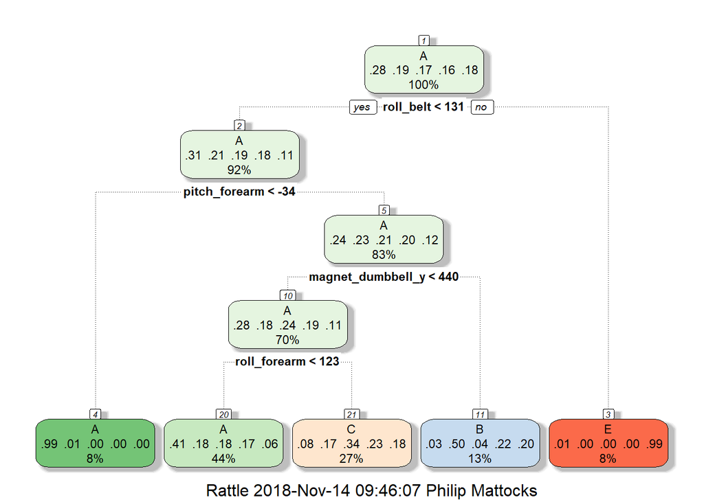

```r
fitModDT <- train(classe~.,data=training,method="rpart")
fancyRpartPlot(fitModDT$finalModel)
```

We preidct for the test set and use a confusion matrix to calculate the out of sample error

```r
predictDT <- predict(fitModDT,newdata=testing)
confusionMatrix(predictDT,testing$classe)
```

```
## Confusion Matrix and Statistics
##
##           Reference
## Prediction    A    B    C    D    E
##          A 1262  378  418  356  144
##          B   20  312   26  141  101
##          C  107  259  411  307  248
##          D    0    0    0    0    0
##          E    6    0    0    0  408
##
## Overall Statistics
##
##                Accuracy : 0.488
##                  95% CI : (0.4739, 0.5021)
##     No Information Rate : 0.2845
##     P-Value [Acc > NIR] : < 2.2e-16
##
##                   Kappa : 0.3307
##  Mcnemar's Test P-Value : NA
##
## Statistics by Class:
##
##                      Class: A Class: B Class: C Class: D Class: E
## Sensitivity            0.9047  0.32877  0.48070   0.0000  0.45283
## Specificity            0.6307  0.92718  0.77254   1.0000  0.99850
## Pos Pred Value         0.4934  0.52000  0.30856      NaN  0.98551
## Neg Pred Value         0.9433  0.85200  0.87570   0.8361  0.89020
## Prevalence             0.2845  0.19352  0.17435   0.1639  0.18373
## Detection Rate         0.2573  0.06362  0.08381   0.0000  0.08320
## Detection Prevalence   0.5216  0.12235  0.27162   0.0000  0.08442
## Balanced Accuracy      0.7677  0.62797  0.62662   0.5000  0.72567
```

We can see that the out of sample accuracy is 48.8% or an out of sample error of 51.2%

## Random Forest Model

We train and display the random forest model:

```r
fitModRF <- train(classe~.,data=training,method="rf")
fitModRF
```

```
## Random Forest
##
## 14718 samples
##    52 predictor
##     5 classes: 'A', 'B', 'C', 'D', 'E'
##
## No pre-processing
## Resampling: Bootstrapped (25 reps)
## Summary of sample sizes: 14718, 14718, 14718, 14718, 14718, 14718, ...
## Resampling results across tuning parameters:
##
##   mtry  Accuracy   Kappa
##    2    0.9894420  0.9866479
##   27    0.9888046  0.9858417
##   52    0.9796306  0.9742384
##
## Accuracy was used to select the optimal model using the largest value.
## The final value used for the model was mtry = 2.
```

We preidct for the test set and use a confusion matrix to calculate the out of sample error

```r
predictRF <- predict(fitModRF,newdata=testing)
confusionMatrix(predictRF,testing$classe)
```

```
## Confusion Matrix and Statistics
##
##           Reference
## Prediction    A    B    C    D    E
##          A 1394    2    0    0    0
##          B    1  944    8    0    0
##          C    0    3  846   17    0
##          D    0    0    1  785    1
##          E    0    0    0    2  900
##
## Overall Statistics
##
##                Accuracy : 0.9929
##                  95% CI : (0.9901, 0.995)
##     No Information Rate : 0.2845
##     P-Value [Acc > NIR] : < 2.2e-16
##
##                   Kappa : 0.991
##  Mcnemar's Test P-Value : NA
##
## Statistics by Class:
##
##                      Class: A Class: B Class: C Class: D Class: E
## Sensitivity            0.9993   0.9947   0.9895   0.9764   0.9989
## Specificity            0.9994   0.9977   0.9951   0.9995   0.9995
## Pos Pred Value         0.9986   0.9906   0.9769   0.9975   0.9978
## Neg Pred Value         0.9997   0.9987   0.9978   0.9954   0.9998
## Prevalence             0.2845   0.1935   0.1743   0.1639   0.1837
## Detection Rate         0.2843   0.1925   0.1725   0.1601   0.1835
## Detection Prevalence   0.2847   0.1943   0.1766   0.1605   0.1839
## Balanced Accuracy      0.9994   0.9962   0.9923   0.9879   0.9992
```

We can see that the out of sample accuracy is 99% or an out of sample error of 1%

## Generalised Boosting Model

We train and display the generalised boosting model:

```r
fitModBO <- train(classe~.,data=training,method="gbm",verbose=F)
fitModBO
```

```
## Stochastic Gradient Boosting
##
## 14718 samples
##    52 predictor
##     5 classes: 'A', 'B', 'C', 'D', 'E'
##
## No pre-processing
## Resampling: Bootstrapped (25 reps)
## Summary of sample sizes: 14718, 14718, 14718, 14718, 14718, 14718, ...
## Resampling results across tuning parameters:
##
##   interaction.depth  n.trees  Accuracy   Kappa
##   1                   50      0.7509047  0.6840690
##   1                  100      0.8191080  0.7709772
##   1                  150      0.8513074  0.8117573
##   2                   50      0.8543438  0.8154091
##   2                  100      0.9042824  0.8788423
##   2                  150      0.9289761  0.9101142
##   3                   50      0.8947422  0.8667225
##   3                  100      0.9397941  0.9238069
##   3                  150      0.9579323  0.9467653
##
## Tuning parameter 'shrinkage' was held constant at a value of 0.1
##
## Tuning parameter 'n.minobsinnode' was held constant at a value of 10
## Accuracy was used to select the optimal model using the largest value.
## The final values used for the model were n.trees = 150,
##  interaction.depth = 3, shrinkage = 0.1 and n.minobsinnode = 10.
```

We preidct for the test set and use a confusion matrix to calculate the out of sample error

```r
predictBO <- predict(fitModBO,newdata=testing)
confusionMatrix(predictBO,testing$classe)
```

```
## Confusion Matrix and Statistics
##
##           Reference
## Prediction    A    B    C    D    E
##          A 1377   29    0    1    5
##          B    9  900   31    3    5
##          C    7   19  811   31    3
##          D    2    1   12  757   13
##          E    0    0    1   12  875
##
## Overall Statistics
##
##                Accuracy : 0.9625
##                  95% CI : (0.9568, 0.9676)
##     No Information Rate : 0.2845
##     P-Value [Acc > NIR] : < 2.2e-16
##
##                   Kappa : 0.9525
##  Mcnemar's Test P-Value : 1.051e-05
##
## Statistics by Class:
##
##                      Class: A Class: B Class: C Class: D Class: E
## Sensitivity            0.9871   0.9484   0.9485   0.9415   0.9711
## Specificity            0.9900   0.9879   0.9852   0.9932   0.9968
## Pos Pred Value         0.9752   0.9494   0.9311   0.9643   0.9854
## Neg Pred Value         0.9948   0.9876   0.9891   0.9886   0.9935
## Prevalence             0.2845   0.1935   0.1743   0.1639   0.1837
## Detection Rate         0.2808   0.1835   0.1654   0.1544   0.1784
## Detection Prevalence   0.2879   0.1933   0.1776   0.1601   0.1811
## Balanced Accuracy      0.9886   0.9681   0.9669   0.9674   0.9839
```

We can see that the out of sample accuracy is 96% or an out of sample error of 4%

## making predictions on the test set

```r
predict(fitModBO,newdata=validating)
```

```
##  [1] B A B A A E D B A A B C B A E E A B B B
## Levels: A B C D E
```